# Assingment_1

Nina Dyatchenko

October 5, 2018

**1.** Work through this lesson on functions: https://swcarpentry.github.io/r-novice-inflammation/02-func-R/

**Defining Function**

```r
fahrenheit_to_kelvin <- function(temp_F) {
  temp_K <- ((temp_F - 32) * (5 / 9)) + 273.15
  return(temp_K)
}
# freezing point of water
fahrenheit_to_kelvin(32)
```

```
## [1] 273.15
```

```r
# boiling point of water
fahrenheit_to_kelvin(212)
```

```
## [1] 373.15
```

```r
kelvin_to_celsius <- function(temp_K) {
  temp_C <- temp_K - 273.15
  return(temp_C)
}
```

**Composing Functions**

```r
# absolute zero in Celsius
kelvin_to_celsius(0)
```

```
## [1] -273.15
```

```r
fahrenheit_to_celsius <- function(temp_F) {
  temp_K <- fahrenheit_to_kelvin(temp_F)
  temp_C <- kelvin_to_celsius(temp_K)
  return(temp_C)
}
```

**Nesting Functions** - “nesting” one function inside another.

```r
# freezing point of water in Celsius
fahrenheit_to_celsius(32.0)
```

```
## [1] 0
```

```r
# freezing point of water in Celsius
kelvin_to_celsius(fahrenheit_to_kelvin(32.0))
```

```
## [1] 0
```

```r
best_practice <- c("Write", "programs", "for", "people", "not", "computers")
asterisk <- "***"  # R interprets a variable with a single value as a vector
                   # with one element.

fence <- function(original, wrapper) {
  answer <- c(wrapper, original, wrapper)
  return(answer)
}
fence(best_practice, asterisk)
```

```
## [1] "***"       "Write"     "programs"  "for"       "people"    "not"
## [7] "computers" "***"
```

```r
outside <- function(v) {
  first <- v[1]
   last <- v[length(v)]
   answer <- c(first, last)
   return(answer)
}
dry_principle <- c("Don't", "repeat", "yourself", "or", "others")
outside(dry_principle)
```

```
## [1] "Don't"  "others"
```

**The Call Stack** - Function calls are managed via the call stack.

**Named Variables and Scope Variables** - Functions can accept arguments explicitly assigned to a variable name in in the function call functionName(variable = value), as well as arguments by order.

```r
input_1 <- 20
mySum <- function(input_1, input_2 = 10) {
  output <- input_1 + input_2
  return(output)
}
mySum(input_1 = 1, 3)
```

```
## [1] 4
```

```r
#mySum(3)
#mySum(input_2=3)
# Error: argument "input_1" is missing, with no default.
```

**Testing and Documenting** - start testing that those functions are working correctly.

```r
center <- function(data, desired) {
  new_data <- (data - mean(data)) + desired
  return(new_data)
}
z <- c(0, 0, 0, 0)
z
```

```
## [1] 0 0 0 0
```

```r
center(z, 3)
```

```
## [1] 3 3 3 3
```

```r
# works right

dat <- read.csv(file = "C:/Users/Nina/Documents/GitHub/BST650_Bootstrap/inflammation-01.csv",
                header = FALSE)
centered <- center(dat[, 4], 0)
head(centered)
```

```
## [1]  1.25 -0.75  1.25 -1.75  1.25  0.25
```

```r
# original min
min(dat[, 4])
```

```
## [1] 0
```

```r
# original mean
mean(dat[, 4])
```

```
## [1] 1.75
```

```r
# original max
max(dat[, 4])
```

```
## [1] 3
```

```r
# centered min
min(centered)
```

```
## [1] -1.75
```

```r
# centered mean
mean(centered)
```

```
## [1] 0
```

```r
# centered max
max(centered)
```

```
## [1] 1.25
```

```r
# original standard deviation
sd(dat[, 4])
```

```
## [1] 1.067628
```

```r
# centered standard deviation
sd(centered)
```

```
## [1] 1.067628
```

```r
# difference in standard deviations before and after
sd(dat[, 4]) - sd(centered)
```

```
## [1] 0
```

```r
all.equal(sd(dat[, 4]), sd(centered))
```

```
## [1] TRUE
```

```r
center <- function(data, desired) {
  # return a new vector containing the original data centered around the
  # desired value.
  # Example: center(c(1, 2, 3), 0) => c(-1, 0, 1)
  new_data <- (data - mean(data)) + desired
  return(new_data)
}
```

**Functions to Create Graphs**

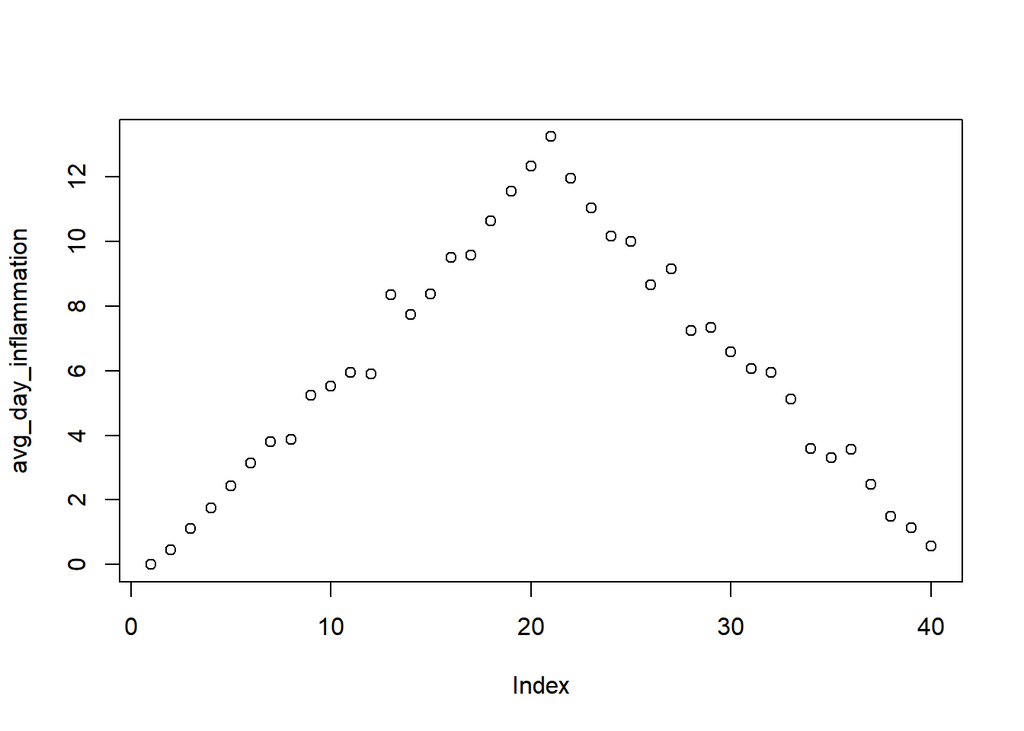

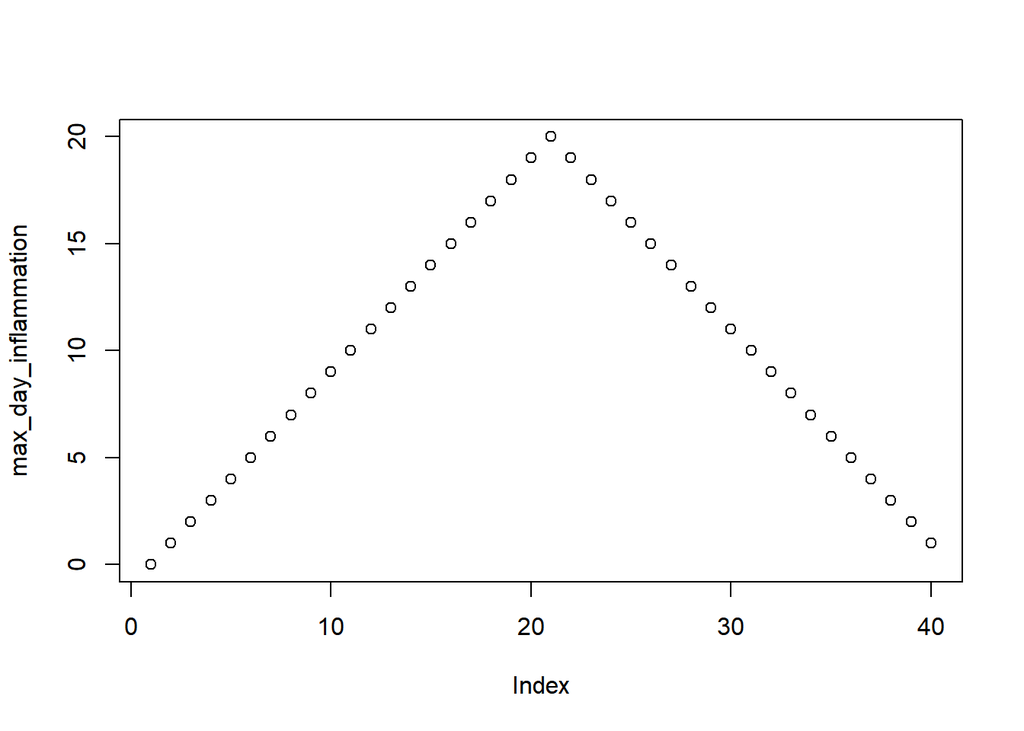

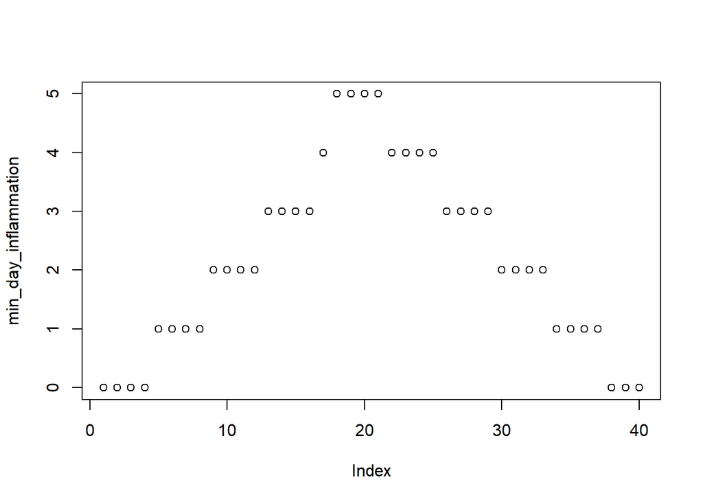

```r
analyze <- function(filename) {
  # Plots the average, min, and max inflammation over time.
  # Input is character string of a csv file.
  dat <- read.csv(file = filename, header = FALSE)
  avg_day_inflammation <- apply(dat, 2, mean)
  plot(avg_day_inflammation)
  max_day_inflammation <- apply(dat, 2, max)
  plot(max_day_inflammation)
  min_day_inflammation <- apply(dat, 2, min)
  plot(min_day_inflammation)
}
analyze("C:/Users/Nina/Documents/GitHub/BST650_Bootstrap/inflammation-01.csv")
```

**Rescaling** - takes a vector as input and returns a corresponding vector of values scaled to lie in the range 0 to 1.

```r
rescale <- function(v) {
  # Rescales a vector, v, to lie in the range 0 to 1.
  L <- min(v) # lowest value
  H <- max(v) # highers value
  result <- (v - L) / (H - L)
  return(result)
}

rescale(1:19)
```

```
##  [1] 0.00000000 0.05555556 0.11111111 0.16666667 0.22222222 0.27777778
##  [7] 0.33333333 0.38888889 0.44444444 0.50000000 0.55555556 0.61111111
## [13] 0.66666667 0.72222222 0.77777778 0.83333333 0.88888889 0.94444444
## [19] 1.00000000
```

**Defining Defaults** - we can pass the arguments to read.csv without naming them.

```r
dat <- read.csv("C:/Users/Nina/Documents/GitHub/BST650_Bootstrap/inflammation-01.csv", FALSE)

#re-define our center function
center <- function(data, desired = 0) {
  # return a new vector containing the original data centered around the
  # desired value (0 by default).
  # Example: center(c(1, 2, 3), 0) => c(-1, 0, 1)
  new_data <- (data - mean(data)) + desired
  return(new_data)
}
test_data <- c(0, 0, 0, 0)
center(test_data, 3)
```

```
## [1] 3 3 3 3
```

```r
more_data <- 5 + test_data
more_data
```

```
## [1] 5 5 5 5
```

```r
center(more_data)
```

```
## [1] 0 0 0 0
```

```r
display <- function(a = 1, b = 2, c = 3) {
  result <- c(a, b, c)
  names(result) <- c("a", "b", "c")  # This names each element of the vector
  return(result)
}

# no arguments
display()
```

```
## a b c
## 1 2 3
```

```r
# one argument
display(55)
```

```
##  a  b  c
## 55  2  3
```

```r
# two arguments
display(55, 66)
```

```
##  a  b  c
## 55 66  3
```

```r
# three arguments
display(55, 66, 77)
```

```
##  a  b  c
## 55 66 77
```

```r
# only setting the value of c
display(c = 77)
```

```
##  a  b  c
##  1  2 77
```

**Matching Arguments** - R has three ways that arguments are supplied by you are matched to the formal arguments of the function definition.

read.csv(file, header = TRUE, sep = “,”, quote = “"”, dec = “.”, fill = TRUE, comment.char = “”, …)

**A Function with Default Argument Values** - Rewrite the rescale function so that it scales a vector to lie between 0 and 1 by default, but will allow the caller to specify lower and upper bounds if they want.

```r
rescale <- function(v, lower = 0, upper = 1) {
  # Rescales a vector, v, to lie in the range lower to upper.
  L <- min(v)
  H <- max(v)
  result <- (v - L) / (H - L) * (upper - lower) + lower
  return(result)
}
```

**2.** Create a function called `bootstrap()` that modifies the behaviour of the `sample()` function to perform a bootstrap sample on a given vector. Remember that bootstrap samples are the same **length** as the original sample, and remember that these samples are taken **with replacement** (*hint, hint*).

```r
bootstrap<- function(data) {
  sample1<- sample(data, size=length(data), replace = T) # sample with replacement
  return(sample1)
  }
```

**3.** Create the following vector: `grades = c(92, 80, 85, 95, 97, 78, 90, 86, 88, 66, 70, 82)`. Find the five-number summary, mean, and standard deviation of `grades`.

```r
grades = c(92, 80, 85, 95, 97, 78, 90, 86, 88, 66, 70, 82)
summary(grades)
```

```
##    Min. 1st Qu.  Median    Mean 3rd Qu.    Max.
##   66.00   79.50   85.50   84.08   90.50   97.00
```

```r
sd(grades)
```

```
## [1] 9.472048
```

**4.** Call your function 10 times on `grades`. Store each bootstrapped sample as `boot1`, `boot2`, …, `boot10`.

```r
boot1<- bootstrap(grades)
boot2<- bootstrap(grades)
boot3<- bootstrap(grades)
boot4<- bootstrap(grades)
boot5<- bootstrap(grades)
boot6<- bootstrap(grades)
boot7<- bootstrap(grades)
boot8<- bootstrap(grades)
boot9<- bootstrap(grades)
boot10<- bootstrap(grades)
```

**5.** Find the five-number summary, mean, and standard deviation of each bootstrap sample.

```r
summary(boot1)
```

```
##    Min. 1st Qu.  Median    Mean 3rd Qu.    Max.
##   66.00   79.00   86.00   83.67   88.50   97.00
```

```r
sd(boot1)
```

```
## [1] 9.948351
```

```r
summary(boot2)
```

```
##    Min. 1st Qu.  Median    Mean 3rd Qu.    Max.
##   66.00   69.00   79.00   79.00   86.25   95.00
```

```r
sd(boot2)
```

```
## [1] 10.36603
```

```r
summary(boot3)
```

```
##    Min. 1st Qu.  Median    Mean 3rd Qu.    Max.
##    66.0    81.5    87.0    86.0    90.5    97.0
```

```r
sd(boot3)
```

```
## [1] 8.323024
```

```r
summary(boot4)
```

```
##    Min. 1st Qu.  Median    Mean 3rd Qu.    Max.
##   66.00   76.00   80.00   79.92   85.00   97.00
```

```r
sd(boot4)
```

```
## [1] 8.628266
```

```r
summary(boot5)
```

```
##    Min. 1st Qu.  Median    Mean 3rd Qu.    Max.
##   66.00   76.00   78.00   81.17   90.00   97.00
```

```r
sd(boot5)
```

```
## [1] 10.74357
```

```r
summary(boot6)
```

```
##    Min. 1st Qu.  Median    Mean 3rd Qu.    Max.
##   66.00   81.00   83.50   83.83   90.00   97.00
```

```r
sd(boot6)
```

```
## [1] 7.918142
```

```r
summary(boot7)
```

```
##    Min. 1st Qu.  Median    Mean 3rd Qu.    Max.
##   66.00   76.00   81.00   81.08   88.50   95.00
```

```r
sd(boot7)
```

```
## [1] 9.792932
```

```r
summary(boot8)
```

```
##    Min. 1st Qu.  Median    Mean 3rd Qu.    Max.
##   78.00   84.25   88.00   88.08   92.75   97.00
```

```r
sd(boot8)
```

```
## [1] 6.302356
```

```r
summary(boot9)
```

```
##    Min. 1st Qu.  Median    Mean 3rd Qu.    Max.
##   66.00   69.00   81.00   81.25   92.75   97.00
```

```r
sd(boot9)
```

```
## [1] 12.15151
```

```r
summary(boot10)
```

```
##    Min. 1st Qu.  Median    Mean 3rd Qu.    Max.
##   82.00   85.00   87.00   88.83   92.75   97.00
```

```r
sd(boot10)
```

```
## [1] 5.540485
```

**6.** Create a data frame of these summary statistics (10 rows and seven columns).

```r
BootsFrame <- data.frame(
  Bootstraps = c("boot1", "boot2", "boot3", "boot4", "boot5",
                 "boot6", "boot7", "boot8", "boot9", "boot10"),
  MinBoot = c(min(boot1), min(boot2), min(boot3), min(boot4), min(boot5),
              min(boot6), min(boot7), min(boot8), min(boot9), min(boot10)),
  Quart1 = c(IQR(boot1), IQR(boot2), IQR(boot3), IQR(boot4), IQR(boot5),
             IQR(boot6), IQR(boot7), IQR(boot8), IQR(boot9), IQR(boot10)),
  MedianBoot = c(median(boot1), median(boot2), median(boot3), median(boot4), median(boot5),
                 median(boot6), median(boot7), median(boot8), median(boot9), median(boot10)),
  MeanBoot= c(mean(boot1), mean(boot2), mean(boot3), mean(boot4), mean(boot5),
              mean(boot6), mean(boot7), mean(boot8), mean(boot9), mean(boot10)),
  MaxBoot= c(max(boot1), max(boot2), max(boot3), max(boot4), max(boot5),
             max(boot6), max(boot7), max(boot8), max(boot9), max(boot10)),
  StDev = c(sd(boot1), sd(boot2), sd(boot3), sd(boot4), sd(boot5),
            sd(boot6), sd(boot7), sd(boot8), sd(boot9), sd(boot10)),
  stringsAsFactors = FALSE)

head(BootsFrame)
```

```
##   Bootstraps MinBoot Quart1 MedianBoot MeanBoot MaxBoot     StDev
## 1      boot1      66   9.50       86.0 83.66667      97  9.948351
## 2      boot2      66  17.25       79.0 79.00000      95 10.366028
## 3      boot3      66   9.00       87.0 86.00000      97  8.323024
## 4      boot4      66   9.00       80.0 79.91667      97  8.628266
## 5      boot5      66  14.00       78.0 81.16667      97 10.743567
## 6      boot6      66   9.00       83.5 83.83333      97  7.918142
```

```r
estimateInt <- function(data) {
  return(mean(data))
}
mean1<- estimateInt(BootsFrame$MinBoot)
mean1
```

```
## [1] 68.8
```

```r
mean(BootsFrame$MinBoot)
```

```
## [1] 68.8
```

```r
mean(BootsFrame$Quart1)
```

```
## [1] 12.025
```

```r
mean(BootsFrame$MedianBoot)
```

```
## [1] 83.05
```

```r
mean(BootsFrame$MeanBoot)
```

```
## [1] 83.28333
```

```r
mean(BootsFrame$MaxBoot)
```

```
## [1] 96.6
```

```r
mean(BootsFrame$StDev)
```

```
## [1] 8.971466
```